# Group4-KKT,KYJ,KYR,SJH

# 3-25 Durban

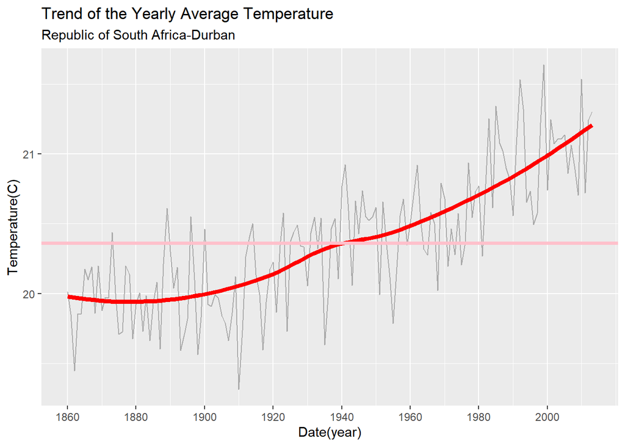

```r
# KIM KYU TAE
# Durban

city5 <- yclean %>% filter(City==part2_cities[4]) %>% na.omit()
city5 %>% group_by(year) %>% summarise(ave = mean(AverageTemperature)) %>% na.omit() %>%
  ggplot() + geom_line(col="dark grey") + aes(x=year, y=ave) + geom_smooth(col='Red', se=F, lwd=1.7)+
  geom_hline(yintercept=mean(city5$AverageTemperature), col='pink', lwd=1.3)+
  labs(title = "Trend of the Yearly Average Temperature", subtitle="Republic of South Africa-Durban", x= "Date(year)", y="Temperature(C)")+
  scale_x_continuous(breaks = seq(1860, 2013, 20))
```

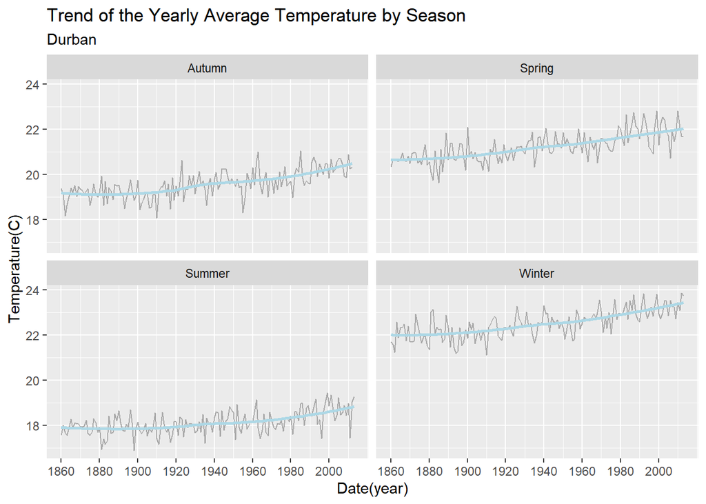

```r
city5 %>% group_by(season, year) %>% summarise(ave = mean(AverageTemperature)) %>% na.omit() %>%
  ggplot() + geom_line(col="dark grey") + aes(x=year, y=ave) + geom_smooth(col='light blue', se=F)+
  labs(title = "Trend of the Yearly Average Temperature by Season", subtitle="Durban", x= "Date(year)", y="Temperature(C)")+
  scale_x_continuous(breaks = seq(1860, 2013, 20))+
  facet_wrap(~season)
```

A port city in eastern South Africa. Iron ore, sugar, etc. are mainly exported as a trade port behind the mining and industrial zone in Transvaal state. Oil, oil, and Jedang industries have developed, and the east Indian Ocean coast is known as a tourist and recreation area. (Coast-Indian Ocean)

# 3-26 Kinshasha

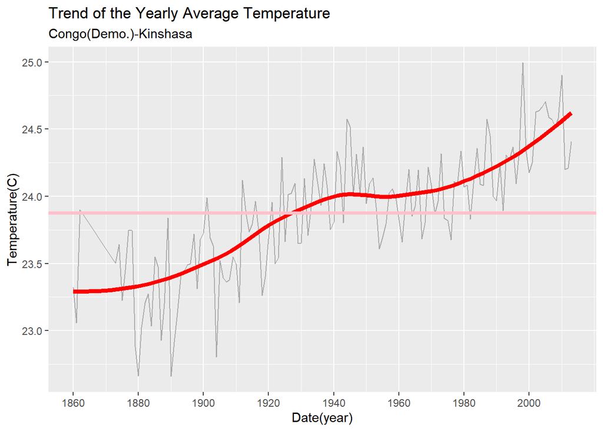

```r
# KIM KYU TAE
# Kinshasha

city6 <- yclean %>% filter(City==part2_cities[25]) %>% na.omit()
city6 %>% group_by(year) %>% summarise(ave = mean(AverageTemperature)) %>% na.omit() %>%
  ggplot() + geom_line(col="dark grey") + aes(x=year, y=ave) + geom_smooth(col='Red', se=F, lwd=1.7)+
  geom_hline(yintercept=mean(city6$AverageTemperature), col='pink', lwd=1.3)+
  labs(title = "Trend of the Yearly Average Temperature", subtitle="Congo(Demo.)-Kinshasa", x= "Date(year)", y="Temperature(C)")+
  scale_x_continuous(breaks = seq(1860, 2013, 20))
```

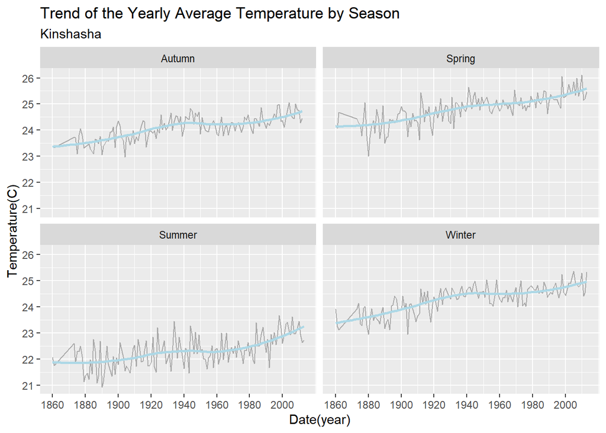

```r
city6 %>% group_by(season, year) %>% summarise(ave = mean(AverageTemperature)) %>% na.omit() %>%
  ggplot() + geom_line(col="dark grey") + aes(x=year, y=ave) + geom_smooth(col='light blue', se=F)+
  labs(title = "Trend of the Yearly Average Temperature by Season", subtitle="Kinshasha", x= "Date(year)", y="Temperature(C)")+
  scale_x_continuous(breaks = seq(1860, 2013, 20))+
  facet_wrap(~season)
```

The capital of the Democratic Republic of Congo. Located on the left side of the Congo River and facing the Brasaville of Congo along the river. It is the political, economic, transportation and cultural center of the Democratic Republic of Congo. Railways stretching from the port of Matadi turn from here into river traffic, and the main stream of the Congo River and the Kasai River connect with the railways, respectively, forming an artery of traffic. Shipbuilding, vehicles, chemicals and textile industries will be in operation. The Kalina district, centered on port and railway stations, is a commercial and industrial district, while the Kinshasa district is a government office district. (Next to the Congo River)

# 3-27 Addis Abeba

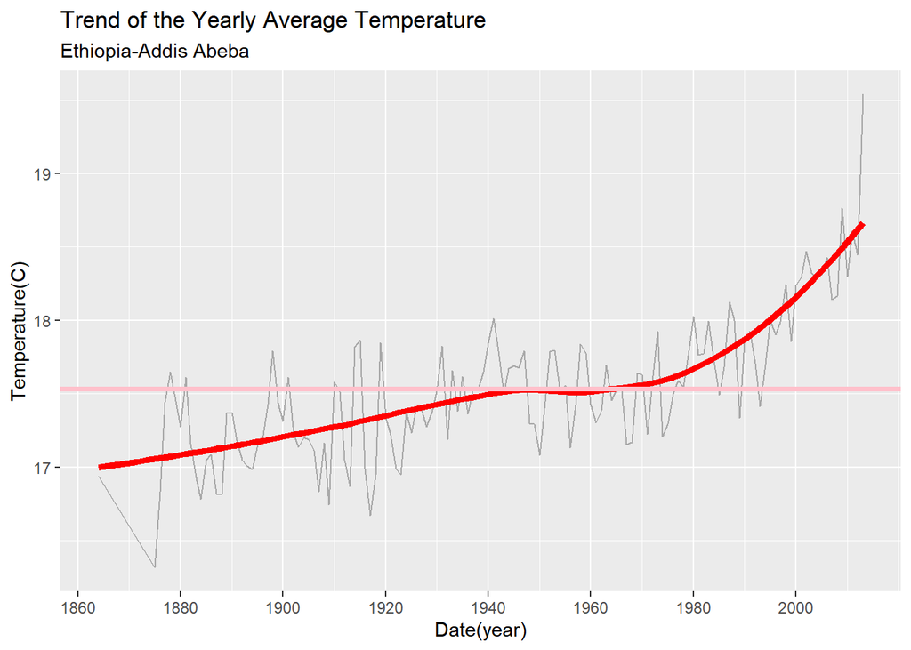

```r
# KIM KYU TAE
# Addis Abeba

city7 <- yclean %>% filter(City==part1_cities[2]) %>% na.omit()
city7 %>% group_by(year) %>% summarise(ave = mean(AverageTemperature)) %>% na.omit() %>%
  ggplot() + geom_line(col="dark grey") + aes(x=year, y=ave) + geom_smooth(col='Red', se=F, lwd=1.7)+
  geom_hline(yintercept=mean(city7$AverageTemperature), col='pink', lwd=1.3)+
  labs(title = "Trend of the Yearly Average Temperature", subtitle="Ethiopia-Addis Abeba", x= "Date(year)", y="Temperature(C)")+
  scale_x_continuous(breaks = seq(1860, 2013, 20))
```

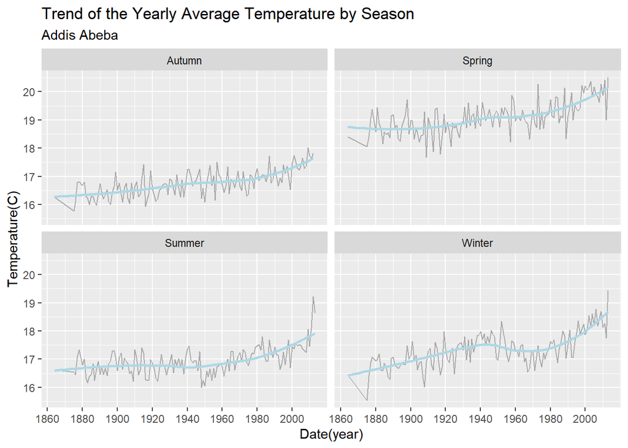

```r
city7 %>% group_by(season, year) %>% summarise(ave = mean(AverageTemperature)) %>% na.omit() %>%
  ggplot() + geom_line(col="dark grey") + aes(x=year, y=ave) + geom_smooth(col='light blue', se=F)+
  labs(title = "Trend of the Yearly Average Temperature by Season", subtitle="Addis Abeba", x= "Date(year)", y="Temperature(C)")+
  scale_x_continuous(breaks = seq(1860, 2013, 20))+
  facet_wrap(~season)
```

capital of Ethiopia It is located on a highlands of 2,400 meters above sea level near the equator, but the climate is pleasant. Modernization began under Italian occupation in 1936 and progressed even after liberation by the British army in 1941. Due to the centralized political system, Addis Ababa has become a national center in all fields, including religion, politics, economics, and education. The tobacco, cement, leather, etc. industries are in operation. Due to the centralized political system, Addis Ababa has become a national center in all fields, including religion, politics, economics, and education, but due to the lack of industrial development, some factories are scattered in and around the city. (Domestic, highlands)